# Automated vehicle Services for People with disabilities – Involved Responsive Engineering (ASPIRE Center)

# Survey response summary

## All participants

### What are the current transportation practices of individuals with disabilities?

#### What are your current modes of transportation?

```r
#transport modes
transport_modes<-domulti_sum(dataf[,14:20])
rownames(transport_modes)<-c("Licensed Driver or Permit holder of a Personally Owned or Leased Vehicle",
                        "Passenger of a Personally Owned or Leased Vehicle",
                        "Ground Public Transportation (e.g., paratransit, fixed route bus, train, subway, etc.)",
                        "Ground Private Transportation (e.g., Uber, Lyft, Taxi)",
                        "Light rail or train air taxi (flying vehicles or drones)",
                        "Air travel (e.g., planes, helicopters)",
                        "Water travel (e.g., boat, ferry, water taxi)")
datatable(transport_modes)
```

|  | n | percent |
| --- | --- | --- |
| Licensed Driver or Permit holder of a Personally Owned or Leased Vehicle | 225 | 45.8248472505092 |
| Passenger of a Personally Owned or Leased Vehicle | 219 | 44.6028513238289 |
| Ground Public Transportation (e.g., paratransit, fixed route bus, train, subway, etc.) | 226 | 46.0285132382892 |
| Ground Private Transportation (e.g., Uber, Lyft, Taxi) | 123 | 25.050916496945 |
| Light rail or train air taxi (flying vehicles or drones) | 135 | 27.4949083503055 |
| Air travel (e.g., planes, helicopters) | 47 | 9.57230142566191 |
| Water travel (e.g., boat, ferry, water taxi) | 34 | 6.92464358452139 |

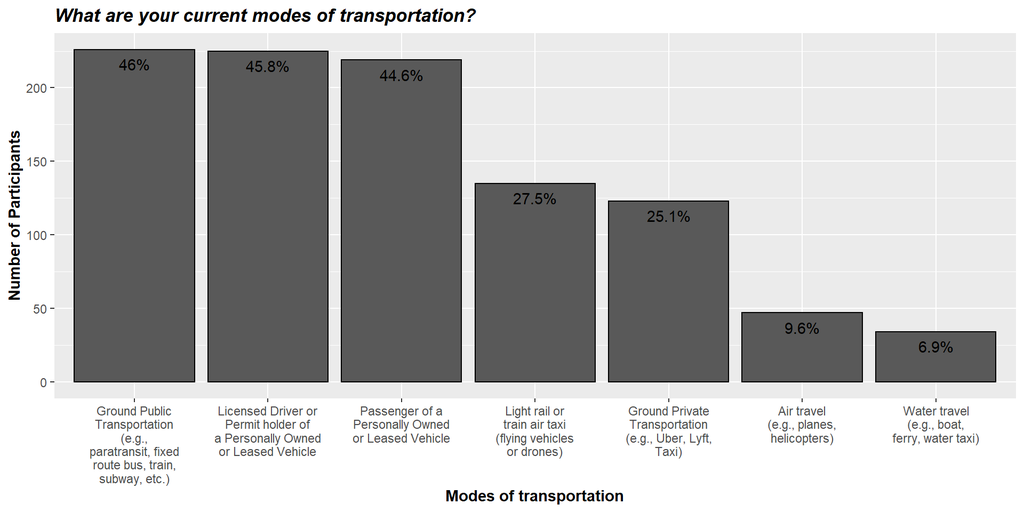

```r
transport_modes%>%
  mutate(x=rownames(transport_modes),
         percent=paste(round(percent,1),"%",sep = ""))%>%
  ggplot(aes(x=reorder(x,-n), y=n,label=percent))+
  geom_bar(stat="identity", color="black")+
  geom_text(nudge_y = -10)+
  xlab("Modes of transportation") +
  ylab("Number of Participants") +
  ggtitle(str_wrap("What are your current modes of transportation?",70))+
  scale_fill_manual(values = "#E63F00")+
  scale_x_discrete(labels = function(x) str_wrap(x, width = 18))+
  theme(
    plot.title = element_text(face="bold.italic"),
    axis.title.x = element_text(face="bold"),
    axis.title.y = element_text(face="bold"))
```

#### Vehicles you would be willing to use:

```r
#av systems
av_systems<-domulti_sum(dataf[,22:27])


rownames(av_systems)<-c("Full-size buses",
                        "Mini-buses or multi-passenger van ride-share",
                        "Van or mini-vans",
                        "Cars",
                        "Light rail or train air taxi (flying vehicles or drones)",
                        "Others")
datatable(av_systems)
```

|  | n | percent |
| --- | --- | --- |
| Full-size buses | 181 | 36.8635437881874 |
| Mini-buses or multi-passenger van ride-share | 254 | 51.7311608961303 |
| Van or mini-vans | 321 | 65.3767820773931 |
| Cars | 305 | 62.1181262729124 |
| Light rail or train air taxi (flying vehicles or drones) | 188 | 38.2892057026477 |
| Others | 28 | 5.70264765784114 |

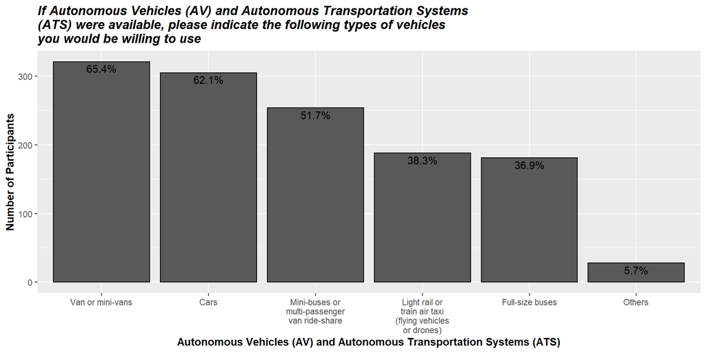

```r
av_systems%>%
  mutate(x=rownames(av_systems),
         percent=paste(round(percent,1),"%",sep = ""))%>%
  ggplot(aes(x=reorder(x,-n), y=n,label=percent))+
  geom_bar(stat="identity", color="black")+
  geom_text(nudge_y = -10)+
  xlab("Autonomous Vehicles (AV) and Autonomous Transportation Systems (ATS)") +
  ylab("Number of Participants") +
  ggtitle(str_wrap("If Autonomous Vehicles (AV) and Autonomous Transportation Systems (ATS) were available, please indicate the following types of vehicles you would be willing to use",70))+
  scale_fill_manual(values = "#E63F00")+
  scale_x_discrete(labels = function(x) str_wrap(x, width = 18))+
  theme(
    plot.title = element_text(face="bold.italic"),
    axis.title.x = element_text(face="bold"),
    axis.title.y = element_text(face="bold"))
```

#### Technologies you would be able to use to arrange a ride in an AV or ATS

```r
#arrg_ride_tech
arrg_ride_tech<-domulti_sum(dataf[,29:35])
datatable(arrg_ride_tech)
```

|  | n | percent |
| --- | --- | --- |
| arrg_ride_tech___1 | 418 | 85.132382892057 |
| arrg_ride_tech___2 | 163 | 33.1975560081466 |
| arrg_ride_tech___3 | 110 | 22.4032586558045 |
| arrg_ride_tech___4 | 215 | 43.7881873727088 |
| arrg_ride_tech___5 | 305 | 62.1181262729124 |
| arrg_ride_tech___7 | 13 | 2.64765784114053 |
| arrg_ride_tech___8 | 11 | 2.24032586558045 |

#### Methods you would be willing to use to arrange a ride in an AV or ATS

```r
#meth_arrg_ride___1
meth_arrg_ride<-domulti_sum(dataf[,37:43])
datatable(meth_arrg_ride)
```

|  | n | percent |
| --- | --- | --- |
| meth_arrg_ride___1 | 374 | 76.1710794297352 |
| meth_arrg_ride___2 | 297 | 60.4887983706721 |
| meth_arrg_ride___3 | 286 | 58.2484725050917 |
| meth_arrg_ride___4 | 311 | 63.3401221995927 |
| meth_arrg_ride___5 | 193 | 39.3075356415479 |
| meth_arrg_ride___6 | 151 | 30.7535641547862 |
| meth_arrg_ride___7 | 14 | 2.85132382892057 |

### Activities you would use AV or ATS to access

```r
#activities_access___1
activities_access<-domulti_sum(dataf[,45:51])
datatable(activities_access)
```

|  | n | percent |
| --- | --- | --- |
| activities_access___1 | 387 | 78.8187372708758 |
| activities_access___2 | 316 | 64.3584521384929 |
| activities_access___3 | 209 | 42.5661914460285 |
| activities_access___4 | 312 | 63.5437881873727 |
| activities_access___5 | 311 | 63.3401221995927 |
| activities_access___6 | 318 | 64.7657841140529 |
| activities_access___7 | 26 | 5.29531568228106 |

### Services you would use AV and ATS for:

```r
services_use<-domulti_sum(dataf[,53:58])
datatable(services_use)
```

|  | n | percent |
| --- | --- | --- |
| services_use___1 | 401 | 81.6700610997963 |
| services_use___2 | 197 | 40.122199592668 |
| services_use___3 | 202 | 41.1405295315682 |
| services_use___4 | 157 | 31.9755600814664 |
| services_use___5 | 228 | 46.4358452138493 |
| services_use___6 | 11 | 2.24032586558045 |

### If AV and ATS were available for fixed routes (fixed schedule) similar to public bus schedules, options you would use:

```r
fixed_rte_opt<-domulti_sum(dataf[,61:65])
datatable(fixed_rte_opt)
```

|  | n | percent |
| --- | --- | --- |
| fixed_rte_opt___1 | 199 | 40.5295315682281 |
| fixed_rte_opt___2 | 313 | 63.7474541751528 |
| fixed_rte_opt___3 | 256 | 52.1384928716904 |
| fixed_rte_opt___4 | 172 | 35.030549898167 |
| fixed_rte_opt___5 | 18 | 3.66598778004073 |

### If AV and ATS were available for custom routes (on-demand/not on a fixed schedule, customized pick-up and drop-off points), options you would use:

```r
custom_rtes<-domulti_sum(dataf[,67:71])
datatable(custom_rtes)
```

|  | n | percent |
| --- | --- | --- |
| custom_rtes___1 | 335 | 68.2281059063136 |
| custom_rtes___2 | 201 | 40.9368635437882 |
| custom_rtes___3 | 220 | 44.806517311609 |
| custom_rtes___4 | 194 | 39.5112016293279 |
| custom_rtes___5 | 16 | 3.25865580448065 |

### Accessibility features of an AV and/or ATS you would require

```r
access_features<-domulti_sum(dataf[,73:81])
datatable(access_features)
```

|  | n | percent |
| --- | --- | --- |
| access_features___1 | 290 | 59.0631364562118 |
| access_features___2 | 281 | 57.2301425661914 |
| access_features___3 | 191 | 38.9002036659878 |
| access_features___4 | 195 | 39.7148676171079 |
| access_features___5 | 190 | 38.6965376782077 |
| access_features___6 | 169 | 34.4195519348269 |
| access_features___7 | 198 | 40.3258655804481 |
| access_features___8 | 240 | 48.8798370672098 |
| access_features___9 | 14 | 2.85132382892057 |

### What other forms of transportation would you like to be able to access using AV and ATS?

```r
other_forms_transpo<-domulti_sum(dataf[,85:92])
datatable(other_forms_transpo)
```

|  | n | percent |
| --- | --- | --- |
| other_forms_transpo___1 | 231 | 47.0468431771894 |
| other_forms_transpo___2 | 223 | 45.4175152749491 |
| other_forms_transpo___3 | 184 | 37.4745417515275 |
| other_forms_transpo___4 | 184 | 37.4745417515275 |
| other_forms_transpo___5 | 154 | 31.3645621181263 |
| other_forms_transpo___6 | 199 | 40.5295315682281 |
| other_forms_transpo___7 | 12 | 2.44399185336049 |
| other_forms_transpo___8 | 28 | 5.70264765784114 |

### Which of the following AV services can you see yourself using?

```r
av_services_using<-domulti_sum(dataf[,(96:102)])
datatable(av_services_using)
```

|  | n | percent |
| --- | --- | --- |
| av_services_using___1 | 210 | 42.7698574338086 |
| av_services_using___2 | 164 | 33.4012219959267 |
| av_services_using___3 | 194 | 39.5112016293279 |
| av_services_using___4 | 123 | 25.050916496945 |
| av_services_using___5 | 300 | 61.0997963340122 |
| av_services_using___6 | 210 | 42.7698574338086 |
| av_services_using___7 | 208 | 42.3625254582485 |

### Automated or automated driver assist features would you be interested in having in vehicle:

```r
pers_vehicle_asst_feat<-domulti_sum(dataf[,104:116])
datatable(pers_vehicle_asst_feat)
```

|  | n | percent |
| --- | --- | --- |
| pers_vehicle_asst_feat___1 | 206 | 41.9551934826884 |
| pers_vehicle_asst_feat___2 | 231 | 47.0468431771894 |
| pers_vehicle_asst_feat___3 | 304 | 61.9144602851324 |
| pers_vehicle_asst_feat___4 | 294 | 59.877800407332 |
| pers_vehicle_asst_feat___5 | 247 | 50.3054989816701 |
| pers_vehicle_asst_feat___6 | 238 | 48.4725050916497 |
| pers_vehicle_asst_feat___7 | 245 | 49.89816700611 |
| pers_vehicle_asst_feat___8 | 217 | 44.1955193482688 |
| pers_vehicle_asst_feat___9 | 291 | 59.2668024439918 |
| pers_vehicle_asst_feat___10 | 284 | 57.8411405295316 |

[output cut: 3 more lines]

### Where would a personally owned AV be most valuable to you:

```r
pers_av_value<-domulti_sum(dataf[,118:123])
datatable(pers_av_value)
```

|  | n | percent |
| --- | --- | --- |
| pers_av_value___1 | 310 | 63.1364562118126 |
| pers_av_value___2 | 299 | 60.8961303462322 |
| pers_av_value___3 | 191 | 38.9002036659878 |
| pers_av_value___4 | 278 | 56.6191446028513 |
| pers_av_value___5 | 215 | 43.7881873727088 |
| pers_av_value___6 | 16 | 3.25865580448065 |

```r
library(tidyr)
library("RVAideMemoire")
```

## Survey response summary by disability types

```r
#r
```

### Question 2

```r
#Modify data into long format and display by disability types
dataf$id<-c(1:nrow(dataf))

x.labs<-c("Full-size buses",
  "Mini-buses or multi-passenger van ride-share",
  "Van or mini-vans",
  "Cars",
  "Light rail or train air taxi (flying vehicles or drones)",
  "Others")

#2
q2<-dataf%>%
  gather(TransportModes,
         TransportModesCheck,
         transpo_modes___1:transpo_modes___7,
         factor_key = T)#%>%
#  case_when()

q2$TransportModesFact<-q2$TransportModesCheck=="Checked"


#q2%>%
#  filter(TransportModesCheck=="Checked")%>%
#  group_by(disab_type_2)%>%
#  mutate(percent=(n()/nrow(q2))*100)%>%
#  ggplot(aes(x=disab_type_2,label=percent))+
#  geom_bar(stat = "identity")+
 # facet_wrap(~ disab_type)+
  #geom_text(nudge_y = -10)+
#  xlab("Autonomous Vehicles (AV) and Autonomous Transportation Systems (ATS)") +
#  ylab("Number of Participants")+
#  scale_x_discrete(labels = x.labs)


q2%>%
  group_by(disab_type_2,TransportModes)%>%
  summarize(N_disab=n(), #all the people that responded to the question, i.e. said Yes or No
            n=round(sum(TransportModesCheck=="Checked"),2), #all the people that said Yes
            'n (%)'=paste0
            (
              sum(TransportModesCheck=="Checked"),
              " ",
              "(",
              round(sum(TransportModesCheck=="Checked")/n()*100,2),
              ")"
              )
            )%>%
  datatable()
```

|  | disab_type_2 | TransportModes | N_disab | n | n (%) |
| --- | --- | --- | --- | --- | --- |
| 1 | Ambulatory difficulty | transpo_modes___1 | 164 | 123 | 123 (75) |
| 2 | Ambulatory difficulty | transpo_modes___2 | 164 | 55 | 55 (33.54) |
| 3 | Ambulatory difficulty | transpo_modes___3 | 164 | 60 | 60 (36.59) |
| 4 | Ambulatory difficulty | transpo_modes___4 | 164 | 29 | 29 (17.68) |
| 5 | Ambulatory difficulty | transpo_modes___5 | 164 | 56 | 56 (34.15) |
| 6 | Ambulatory difficulty | transpo_modes___6 | 164 | 15 | 15 (9.15) |
| 7 | Ambulatory difficulty | transpo_modes___7 | 164 | 5 | 5 (3.05) |
| 8 | Cognitive difficulty | transpo_modes___1 | 37 | 13 | 13 (35.14) |
| 9 | Cognitive difficulty | transpo_modes___2 | 37 | 10 | 10 (27.03) |
| 10 | Cognitive difficulty | transpo_modes___3 | 37 | 19 | 19 (51.35) |

[output cut: 39 more lines]

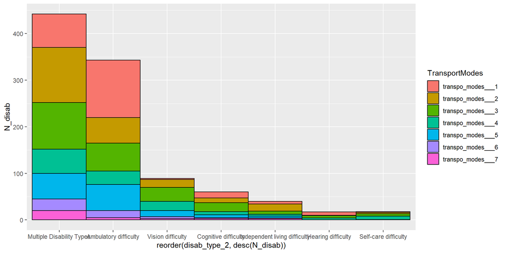

```r
 q2%>%
    group_by(disab_type_2,TransportModes,TransportModesCheck)%>%
    mutate(N_disab=n())%>%
   distinct(disab_type_2,TransportModes,TransportModesCheck,.keep_all = T)%>%
   filter(TransportModesCheck=="Checked")%>%
   ggplot(aes(x=reorder(disab_type_2,desc(N_disab)),y=N_disab))+
   geom_col(aes(fill=TransportModes),width = 1,color="black")
```

```r
xtabs(~TransportModes,
        data = q2%>%
  filter(TransportModesFact==T))
```

```
## TransportModes
## transpo_modes___1 transpo_modes___2 transpo_modes___3 transpo_modes___4
##               225               219               226               123
## transpo_modes___5 transpo_modes___6 transpo_modes___7
##               135                47                34
```

```r
#cochran q test for tmodes
cochran.qtest(formula = TransportModesFact~TransportModes|id,data = q2,alpha = 0.05,p.method = "fdr")
```

```
##
##  Cochran's Q test
##
## data:  TransportModesFact by TransportModes, block = id
## Q = 408.8245, df = 6, p-value < 2.2e-16
## alternative hypothesis: true difference in probabilities is not equal to 0
## sample estimates:
## proba in group transpo_modes___1 proba in group transpo_modes___2
##                       0.45824847                       0.44602851
## proba in group transpo_modes___3 proba in group transpo_modes___4
##                       0.46028513                       0.25050916
## proba in group transpo_modes___5 proba in group transpo_modes___6
##                       0.27494908                       0.09572301
## proba in group transpo_modes___7
##                       0.06924644
##
##         Pairwise comparisons using Wilcoxon sign test
##
##                   transpo_modes___1 transpo_modes___2 transpo_modes___3
## transpo_modes___2         8.146e-01                 -                 -
## transpo_modes___3         1.000e+00         7.779e-01                 -
## transpo_modes___4         6.374e-10         1.844e-10         2.639e-14
## transpo_modes___5         9.258e-10         2.783e-09         9.024e-11
## transpo_modes___6         5.258e-37         8.387e-38         5.382e-41
## transpo_modes___7         5.541e-38         5.523e-40         6.726e-42
##                   transpo_modes___4 transpo_modes___5 transpo_modes___6
## transpo_modes___2                 -                 -                 -
## transpo_modes___3                 -                 -                 -
## transpo_modes___4                 -                 -                 -
## transpo_modes___5         4.153e-01                 -                 -
## transpo_modes___6         2.322e-12         2.355e-20                 -
## transpo_modes___7         1.224e-14         2.956e-17            0.1973
##
## P value adjustment method: fdr
```

```r
#cochran q test for disab types


#transport_modes%>%
#  mutate(x=rownames(transport_modes),
#         percent=paste(round(percent,1),"%",sep = ""))%>%
#  ggplot(aes(x=reorder(x,-n), y=n,label=percent))+
#  geom_bar(stat="identity", color="black")+
#  geom_text(nudge_y = -10)+
#  xlab("Modes of transportation") +
#  ylab("Number of Participants") +
#  ggtitle(str_wrap("What are your current modes of transportation?",70))+
#  scale_fill_manual(values = "#E63F00")+
#  scale_x_discrete(labels = function(x) str_wrap(x, width = 18))+
#  theme(
#    plot.title = element_text(face="bold.italic"),
#    axis.title.x = element_text(face="bold"),
#    axis.title.y = element_text(face="bold"))
```

## Question 3

```r
#3
q3<-dataf%>%
  gather(AVsystems,
         AVsystemsCheck,
         av_systems___1:av_systems___6,
         factor_key = T)

q3$AVsystemsFact<-q3$AVsystemsCheck=="Checked"


q3%>%
  group_by(disab_type,AVsystems)%>%
  summarize(N_disab=n(),
            'n (%)'=paste0
            (
              sum(AVsystemsCheck=="Checked"),
              " ",
              "(",
              round(sum(AVsystemsCheck=="Checked")/n()*100,2),
              ")"
              )
            )%>%
  datatable()
```

|  | disab_type | AVsystems | N_disab | n (%) |
| --- | --- | --- | --- | --- |
| 1 | Ambulatory difficulty | av_systems___1 | 200 | 78 (39) |
| 2 | Ambulatory difficulty | av_systems___2 | 200 | 104 (52) |
| 3 | Ambulatory difficulty | av_systems___3 | 200 | 129 (64.5) |
| 4 | Ambulatory difficulty | av_systems___4 | 200 | 128 (64) |
| 5 | Ambulatory difficulty | av_systems___5 | 200 | 84 (42) |
| 6 | Ambulatory difficulty | av_systems___6 | 200 | 14 (7) |
| 7 | Cognitive difficulty | av_systems___1 | 46 | 14 (30.43) |
| 8 | Cognitive difficulty | av_systems___2 | 46 | 23 (50) |
| 9 | Cognitive difficulty | av_systems___3 | 46 | 19 (41.3) |
| 10 | Cognitive difficulty | av_systems___4 | 46 | 30 (65.22) |

[output cut: 26 more lines]

```r
xtabs(~AVsystems,
        data = q3%>%
  filter(AVsystemsFact==T))
```

```
## AVsystems
## av_systems___1 av_systems___2 av_systems___3 av_systems___4 av_systems___5
##            181            254            321            305            188
## av_systems___6
##             28
```

```r
#cochran q test for tmodes
cochran.qtest(formula = AVsystemsFact~AVsystems|id,data = q3,alpha = 0.05,p.method = "fdr")
```

```
##
##  Cochran's Q test
##
## data:  AVsystemsFact by AVsystems, block = id
## Q = 535.5881, df = 5, p-value < 2.2e-16
## alternative hypothesis: true difference in probabilities is not equal to 0
## sample estimates:
## proba in group av_systems___1 proba in group av_systems___2
##                    0.36863544                    0.51731161
## proba in group av_systems___3 proba in group av_systems___4
##                    0.65376782                    0.62118126
## proba in group av_systems___5 proba in group av_systems___6
##                    0.38289206                    0.05702648
##
##         Pairwise comparisons using Wilcoxon sign test
##
##                av_systems___1 av_systems___2 av_systems___3 av_systems___4
## av_systems___2      1.976e-09              -              -              -
## av_systems___3      1.543e-24      7.567e-07              -              -
## av_systems___4      5.921e-16      7.545e-04      3.589e-01              -
## av_systems___5      5.946e-01      1.165e-07      1.850e-22      3.942e-15
## av_systems___6      2.700e-30      1.974e-49      5.774e-69      1.637e-65
##                av_systems___5
## av_systems___2              -
## av_systems___3              -
## av_systems___4              -
## av_systems___5              -
## av_systems___6      2.271e-32
##
## P value adjustment method: fdr
```

## Question 4

```r
#q4
q4<-dataf%>%
  gather(TechArrangeride,
         ArrangerideCheck,
         arrg_ride_tech___1:arrg_ride_tech___8,
         factor_key = T)

q4$ArrangerideFact<-q4$ArrangerideCheck=="Checked"


q4%>%
  group_by(disab_type,TechArrangeride)%>%
  summarize(N_disab=n(),
            'n (%)'=paste0
            (
              sum(ArrangerideCheck=="Checked"),
              " ",
              "(",
              round(sum(ArrangerideCheck=="Checked")/n()*100,2),
              ")"
              )
            )%>%
  datatable()
```

|  | disab_type | TechArrangeride | N_disab | n (%) |
| --- | --- | --- | --- | --- |
| 1 | Ambulatory difficulty | arrg_ride_tech___1 | 200 | 185 (92.5) |
| 2 | Ambulatory difficulty | arrg_ride_tech___2 | 200 | 82 (41) |
| 3 | Ambulatory difficulty | arrg_ride_tech___3 | 200 | 44 (22) |
| 4 | Ambulatory difficulty | arrg_ride_tech___4 | 200 | 96 (48) |
| 5 | Ambulatory difficulty | arrg_ride_tech___5 | 200 | 136 (68) |
| 6 | Ambulatory difficulty | arrg_ride_tech___7 | 200 | 4 (2) |
| 7 | Ambulatory difficulty | arrg_ride_tech___8 | 200 | 3 (1.5) |
| 8 | Cognitive difficulty | arrg_ride_tech___1 | 46 | 32 (69.57) |
| 9 | Cognitive difficulty | arrg_ride_tech___2 | 46 | 7 (15.22) |
| 10 | Cognitive difficulty | arrg_ride_tech___3 | 46 | 15 (32.61) |

[output cut: 32 more lines]

```r
xtabs(~TechArrangeride,
        data = q4%>%
  filter(ArrangerideFact==T))
```

```
## TechArrangeride
## arrg_ride_tech___1 arrg_ride_tech___2 arrg_ride_tech___3 arrg_ride_tech___4
##                418                163                110                215
## arrg_ride_tech___5 arrg_ride_tech___7 arrg_ride_tech___8
##                305                 13                 11
```

```r
#cochran q test for tmodes
cochran.qtest(formula = ArrangerideFact~TechArrangeride|id,data = q4,alpha = 0.05,p.method = "fdr")
```

```
##
##  Cochran's Q test
##
## data:  ArrangerideFact by TechArrangeride, block = id
## Q = 1172.351, df = 6, p-value < 2.2e-16
## alternative hypothesis: true difference in probabilities is not equal to 0
## sample estimates:
## proba in group arrg_ride_tech___1 proba in group arrg_ride_tech___2
##                        0.85132383                        0.33197556
## proba in group arrg_ride_tech___3 proba in group arrg_ride_tech___4
##                        0.22403259                        0.43788187
## proba in group arrg_ride_tech___5 proba in group arrg_ride_tech___7
##                        0.62118126                        0.02647658
## proba in group arrg_ride_tech___8
##                        0.02240326
##
##         Pairwise comparisons using Wilcoxon sign test
##
##                    arrg_ride_tech___1 arrg_ride_tech___2 arrg_ride_tech___3
## arrg_ride_tech___2          2.006e-52                  -                  -
## arrg_ride_tech___3          1.376e-63          1.105e-04                  -
## arrg_ride_tech___4          3.014e-45          4.001e-04          3.155e-13
## arrg_ride_tech___5          5.714e-19          8.057e-22          1.889e-35
## arrg_ride_tech___7         1.198e-114          5.177e-37          2.224e-24
## arrg_ride_tech___8         6.105e-115          1.569e-37          4.610e-23
##                    arrg_ride_tech___4 arrg_ride_tech___5 arrg_ride_tech___7
## arrg_ride_tech___2                  -                  -                  -
## arrg_ride_tech___3                  -                  -                  -
## arrg_ride_tech___4                  -                  -                  -
## arrg_ride_tech___5          2.463e-11                  -                  -
## arrg_ride_tech___7          2.916e-53          3.429e-79                  -
## arrg_ride_tech___8          8.996e-54          1.189e-79             0.8388
##
## P value adjustment method: fdr
```

## Question 5

```r
#q5
q5<-dataf%>%
  gather(MethodArrangeride,
         MethodArrangerideCheck,
         meth_arrg_ride___1:meth_arrg_ride___7,
         factor_key = T)


q5$MethodArrangerideFact<-q5$MethodArrangerideCheck=="Checked"


q5%>%
  group_by(disab_type,MethodArrangeride)%>%
  summarize(N_disab=n(),
            'n (%)'=paste0
            (
              sum(MethodArrangerideCheck=="Checked"),
              " ",
              "(",
              round(sum(MethodArrangerideCheck=="Checked")/n()*100,2),
              ")"
              )
            )%>%
  datatable()
```

|  | disab_type | MethodArrangeride | N_disab | n (%) |
| --- | --- | --- | --- | --- |
| 1 | Ambulatory difficulty | meth_arrg_ride___1 | 200 | 163 (81.5) |
| 2 | Ambulatory difficulty | meth_arrg_ride___2 | 200 | 131 (65.5) |
| 3 | Ambulatory difficulty | meth_arrg_ride___3 | 200 | 125 (62.5) |
| 4 | Ambulatory difficulty | meth_arrg_ride___4 | 200 | 136 (68) |
| 5 | Ambulatory difficulty | meth_arrg_ride___5 | 200 | 85 (42.5) |
| 6 | Ambulatory difficulty | meth_arrg_ride___6 | 200 | 80 (40) |
| 7 | Ambulatory difficulty | meth_arrg_ride___7 | 200 | 4 (2) |
| 8 | Cognitive difficulty | meth_arrg_ride___1 | 46 | 29 (63.04) |
| 9 | Cognitive difficulty | meth_arrg_ride___2 | 46 | 16 (34.78) |
| 10 | Cognitive difficulty | meth_arrg_ride___3 | 46 | 20 (43.48) |

[output cut: 32 more lines]

```r
xtabs(~MethodArrangeride,
        data = q5%>%
  filter(MethodArrangerideFact==T))
```

```
## MethodArrangeride
## meth_arrg_ride___1 meth_arrg_ride___2 meth_arrg_ride___3 meth_arrg_ride___4
##                374                297                286                311
## meth_arrg_ride___5 meth_arrg_ride___6 meth_arrg_ride___7
##                193                151                 14
```

```r
#cochran q test for tmodes
cochran.qtest(formula = MethodArrangerideFact~MethodArrangeride|id,data = q5,alpha = 0.05,p.method = "fdr")
```

```
##
##  Cochran's Q test
##
## data:  MethodArrangerideFact by MethodArrangeride, block = id
## Q = 824.7489, df = 6, p-value < 2.2e-16
## alternative hypothesis: true difference in probabilities is not equal to 0
## sample estimates:
## proba in group meth_arrg_ride___1 proba in group meth_arrg_ride___2
##                        0.76171079                        0.60488798
## proba in group meth_arrg_ride___3 proba in group meth_arrg_ride___4
##                        0.58248473                        0.63340122
## proba in group meth_arrg_ride___5 proba in group meth_arrg_ride___6
##                        0.39307536                        0.30753564
## proba in group meth_arrg_ride___7
##                        0.02851324
##
##         Pairwise comparisons using Wilcoxon sign test
##
##                    meth_arrg_ride___1 meth_arrg_ride___2 meth_arrg_ride___3
## meth_arrg_ride___2          1.712e-09                  -                  -
## meth_arrg_ride___3          1.402e-14          3.930e-01                  -
## meth_arrg_ride___4          1.164e-05          3.602e-01          9.440e-02
## meth_arrg_ride___5          1.547e-32          4.337e-13          6.859e-11
## meth_arrg_ride___6          8.515e-50          4.289e-29          2.216e-24
## meth_arrg_ride___7          2.691e-94          1.756e-73          1.453e-69
##                    meth_arrg_ride___4 meth_arrg_ride___5 meth_arrg_ride___6
## meth_arrg_ride___2                  -                  -                  -
## meth_arrg_ride___3                  -                  -                  -
## meth_arrg_ride___4                  -                  -                  -
## meth_arrg_ride___5          1.497e-18                  -                  -
## meth_arrg_ride___6          1.259e-30          1.973e-03                  -
## meth_arrg_ride___7          1.989e-76          9.478e-43          2.239e-31
##
## P value adjustment method: fdr
```

## Question 6

```r
#q6
q6<-dataf%>%
  gather(MethodArrangeride,
         MethodArrangerideCheck,
         meth_arrg_ride___1:meth_arrg_ride___7,
         factor_key = T)
```

## Question 7

```r
#q7
q7<-dataf%>%
  gather(Activities_access,
         Activities_accessCheck,
         activities_access___1:activities_access___7,
         factor_key = T)



q7$Activities_accessFact<-q7$Activities_accessCheck=="Checked"


q7%>%
  group_by(disab_type,Activities_access)%>%
  summarize(N_disab=n(),
            'n (%)'=paste0
            (
              sum(Activities_accessCheck=="Checked"),
              " ",
              "(",
              round(sum(Activities_accessCheck=="Checked")/n()*100,2),
              ")"
              )
            )%>%
  datatable()
```

|  | disab_type | Activities_access | N_disab | n (%) |
| --- | --- | --- | --- | --- |
| 1 | Ambulatory difficulty | activities_access___1 | 200 | 167 (83.5) |
| 2 | Ambulatory difficulty | activities_access___2 | 200 | 121 (60.5) |
| 3 | Ambulatory difficulty | activities_access___3 | 200 | 63 (31.5) |
| 4 | Ambulatory difficulty | activities_access___4 | 200 | 129 (64.5) |
| 5 | Ambulatory difficulty | activities_access___5 | 200 | 123 (61.5) |
| 6 | Ambulatory difficulty | activities_access___6 | 200 | 137 (68.5) |
| 7 | Ambulatory difficulty | activities_access___7 | 200 | 11 (5.5) |
| 8 | Cognitive difficulty | activities_access___1 | 46 | 28 (60.87) |
| 9 | Cognitive difficulty | activities_access___2 | 46 | 25 (54.35) |
| 10 | Cognitive difficulty | activities_access___3 | 46 | 23 (50) |

[output cut: 32 more lines]

```r
xtabs(~Activities_access,
        data = q7%>%
  filter(Activities_accessFact==T))
```

```
## Activities_access
## activities_access___1 activities_access___2 activities_access___3
##                   387                   316                   209
## activities_access___4 activities_access___5 activities_access___6
##                   312                   311                   318
## activities_access___7
##                    26
```

```r
#cochran q test for tmodes
cochran.qtest(formula = Activities_accessFact~Activities_access|id,data = q7,alpha = 0.05,p.method = "fdr")
```

```
##
##  Cochran's Q test
##
## data:  Activities_accessFact by Activities_access, block = id
## Q = 823.2399, df = 6, p-value < 2.2e-16
## alternative hypothesis: true difference in probabilities is not equal to 0
## sample estimates:
## proba in group activities_access___1 proba in group activities_access___2
##                           0.78818737                           0.64358452
## proba in group activities_access___3 proba in group activities_access___4
##                           0.42566191                           0.63543788
## proba in group activities_access___5 proba in group activities_access___6
##                           0.63340122                           0.64765784
## proba in group activities_access___7
##                           0.05295316
##
##         Pairwise comparisons using Wilcoxon sign test
##
##                       activities_access___1 activities_access___2
## activities_access___2             7.891e-08                     -
## activities_access___3             7.895e-32             3.149e-13
## activities_access___4             2.176e-11             8.794e-01
## activities_access___5             3.116e-09             8.652e-01
## activities_access___6             3.239e-09             9.803e-01
## activities_access___7             1.382e-94             1.427e-70
##                       activities_access___3 activities_access___4
## activities_access___2                     -                     -
## activities_access___3                     -                     -
## activities_access___4             4.658e-13                     -
## activities_access___5             1.309e-13             1.000e+00
## activities_access___6             7.091e-14             7.829e-01
## activities_access___7             2.813e-40             2.554e-70
##                       activities_access___5 activities_access___6
## activities_access___2                     -                     -
## activities_access___3                     -                     -
## activities_access___4                     -                     -
## activities_access___5                     -                     -
## activities_access___6             7.804e-01                     -
## activities_access___7             2.153e-69             1.045e-71
##
## P value adjustment method: fdr
```

## Question 8

```r
#q8
q8<-dataf%>%
  gather(Services_use,
         Services_useCheck,
         services_use___1:services_use___6,
         factor_key = T)

q8$Services_useFact<-q8$Services_useCheck=="Checked"

q8%>%
  group_by(disab_type,Services_use)%>%
  summarize(N_disab=n(),
            'n (%)'=paste0
            (
              sum(Services_useCheck=="Checked"),
              " ",
              "(",
              round(sum(Services_useCheck=="Checked")/n()*100,2),
              ")"
              )
            )%>%
  datatable()
```

|  | disab_type | Services_use | N_disab | n (%) |
| --- | --- | --- | --- | --- |
| 1 | Ambulatory difficulty | services_use___1 | 200 | 176 (88) |
| 2 | Ambulatory difficulty | services_use___2 | 200 | 65 (32.5) |
| 3 | Ambulatory difficulty | services_use___3 | 200 | 73 (36.5) |
| 4 | Ambulatory difficulty | services_use___4 | 200 | 68 (34) |
| 5 | Ambulatory difficulty | services_use___5 | 200 | 91 (45.5) |
| 6 | Ambulatory difficulty | services_use___6 | 200 | 4 (2) |
| 7 | Cognitive difficulty | services_use___1 | 46 | 28 (60.87) |
| 8 | Cognitive difficulty | services_use___2 | 46 | 18 (39.13) |
| 9 | Cognitive difficulty | services_use___3 | 46 | 16 (34.78) |
| 10 | Cognitive difficulty | services_use___4 | 46 | 9 (19.57) |

[output cut: 26 more lines]

```r
xtabs(~Services_use,
        data = q8%>%
  filter(Services_useFact==T))
```

```
## Services_use
## services_use___1 services_use___2 services_use___3 services_use___4
##              401              197              202              157
## services_use___5 services_use___6
##              228               11
```

```r
#cochran q test for tmodes
cochran.qtest(formula = Services_useFact~Services_use|id,data = q8,alpha = 0.05,p.method = "fdr")
```

```
##
##  Cochran's Q test
##
## data:  Services_useFact by Services_use, block = id
## Q = 688.1072, df = 5, p-value < 2.2e-16
## alternative hypothesis: true difference in probabilities is not equal to 0
## sample estimates:
## proba in group services_use___1 proba in group services_use___2
##                      0.81670061                      0.40122200
## proba in group services_use___3 proba in group services_use___4
##                      0.41140530                      0.31975560
## proba in group services_use___5 proba in group services_use___6
##                      0.46435845                      0.02240326
##
##         Pairwise comparisons using Wilcoxon sign test
##
##                  services_use___1 services_use___2 services_use___3
## services_use___2        5.843e-40                -                -
## services_use___3        4.023e-35        7.831e-01                -
## services_use___4        2.487e-49        7.106e-03        2.010e-03
## services_use___5        1.306e-30        3.829e-02        6.654e-02
## services_use___6       3.853e-103        1.106e-47        7.443e-47
##                  services_use___4 services_use___5
## services_use___2                -                -
## services_use___3                -                -
## services_use___4                -                -
## services_use___5        2.542e-09                -
## services_use___6        7.627e-36         2.85e-56
##
## P value adjustment method: fdr
```

## Question 9

```r
#q9
q9<-dataf%>%
  gather(fixed_routes,
         fixed_routesCheck,
         fixed_rte_opt___1:fixed_rte_opt___5,
         factor_key = T)

q9$fixed_routesFact<-q9$fixed_routesCheck=="Checked"

q9%>%
  group_by(disab_type,fixed_routes)%>%
  summarize(N_disab=n(),
            'n (%)'=paste0
            (
              sum(fixed_routesCheck=="Checked"),
              " ",
              "(",
              round(sum(fixed_routesCheck=="Checked")/n()*100,2),
              ")"
              )
            )%>%
  datatable()
```

|  | disab_type | fixed_routes | N_disab | n (%) |
| --- | --- | --- | --- | --- |
| 1 | Ambulatory difficulty | fixed_rte_opt___1 | 200 | 96 (48) |
| 2 | Ambulatory difficulty | fixed_rte_opt___2 | 200 | 122 (61) |
| 3 | Ambulatory difficulty | fixed_rte_opt___3 | 200 | 107 (53.5) |
| 4 | Ambulatory difficulty | fixed_rte_opt___4 | 200 | 64 (32) |
| 5 | Ambulatory difficulty | fixed_rte_opt___5 | 200 | 8 (4) |
| 6 | Cognitive difficulty | fixed_rte_opt___1 | 46 | 10 (21.74) |
| 7 | Cognitive difficulty | fixed_rte_opt___2 | 46 | 27 (58.7) |
| 8 | Cognitive difficulty | fixed_rte_opt___3 | 46 | 24 (52.17) |
| 9 | Cognitive difficulty | fixed_rte_opt___4 | 46 | 10 (21.74) |
| 10 | Cognitive difficulty | fixed_rte_opt___5 | 46 | 1 (2.17) |

[output cut: 20 more lines]

```r
xtabs(~fixed_routes,
        data = q9%>%
  filter(fixed_routesFact==T))
```

```
## fixed_routes
## fixed_rte_opt___1 fixed_rte_opt___2 fixed_rte_opt___3 fixed_rte_opt___4
##               199               313               256               172
## fixed_rte_opt___5
##                18
```

```r
#cochran q test for tmodes
cochran.qtest(formula = fixed_routesFact~fixed_routes|id,data = q9,alpha = 0.05,p.method = "fdr")
```

```
##
##  Cochran's Q test
##
## data:  fixed_routesFact by fixed_routes, block = id
## Q = 422.3843, df = 4, p-value < 2.2e-16
## alternative hypothesis: true difference in probabilities is not equal to 0
## sample estimates:
## proba in group fixed_rte_opt___1 proba in group fixed_rte_opt___2
##                       0.40529532                       0.63747454
## proba in group fixed_rte_opt___3 proba in group fixed_rte_opt___4
##                       0.52138493                       0.35030550
## proba in group fixed_rte_opt___5
##                       0.03665988
##
##         Pairwise comparisons using Wilcoxon sign test
##
##                   fixed_rte_opt___1 fixed_rte_opt___2 fixed_rte_opt___3
## fixed_rte_opt___2         1.131e-12                 -                 -
## fixed_rte_opt___3         1.428e-04         3.854e-04                 -
## fixed_rte_opt___4         4.012e-02         2.975e-21         6.833e-08
## fixed_rte_opt___5         9.107e-40         8.072e-72         5.814e-55
##                   fixed_rte_opt___4
## fixed_rte_opt___2                 -
## fixed_rte_opt___3                 -
## fixed_rte_opt___4                 -
## fixed_rte_opt___5         2.838e-33
##
## P value adjustment method: fdr
```

## Question 10

```r
#q10
q10<-dataf%>%
  gather(access_features,
            access_featuresCheck,
            access_features___1:access_features___9,
         factor_key = T)

q10$access_featuresFact<-q10$access_featuresCheck=="Checked"

q10%>%
  group_by(disab_type,access_features)%>%
  summarize(N_disab=n(),
            'n (%)'=paste0
            (
              sum(access_featuresCheck=="Checked"),
              " ",
              "(",
              round(sum(access_featuresCheck=="Checked")/n()*100,2),
              ")"
              )
            )%>%
  datatable()
```

|  | disab_type | access_features | N_disab | n (%) |
| --- | --- | --- | --- | --- |
| 1 | Ambulatory difficulty | access_features___1 | 200 | 98 (49) |
| 2 | Ambulatory difficulty | access_features___2 | 200 | 122 (61) |
| 3 | Ambulatory difficulty | access_features___3 | 200 | 79 (39.5) |
| 4 | Ambulatory difficulty | access_features___4 | 200 | 82 (41) |
| 5 | Ambulatory difficulty | access_features___5 | 200 | 61 (30.5) |
| 6 | Ambulatory difficulty | access_features___6 | 200 | 77 (38.5) |
| 7 | Ambulatory difficulty | access_features___7 | 200 | 90 (45) |
| 8 | Ambulatory difficulty | access_features___8 | 200 | 116 (58) |
| 9 | Ambulatory difficulty | access_features___9 | 200 | 7 (3.5) |
| 10 | Cognitive difficulty | access_features___1 | 46 | 33 (71.74) |

[output cut: 44 more lines]

```r
xtabs(~access_features,
        data = q10%>%
  filter(access_featuresFact==T))
```

```
## access_features
## access_features___1 access_features___2 access_features___3 access_features___4
##                 290                 281                 191                 195
## access_features___5 access_features___6 access_features___7 access_features___8
##                 190                 169                 198                 240
## access_features___9
##                  14
```

```r
#cochran q test for tmodes
cochran.qtest(formula = access_featuresFact~access_features|id,data = q10,alpha = 0.05,p.method = "fdr")
```

```
##
##  Cochran's Q test
##
## data:  access_featuresFact by access_features, block = id
## Q = 514.2851, df = 8, p-value < 2.2e-16
## alternative hypothesis: true difference in probabilities is not equal to 0
## sample estimates:
## proba in group access_features___1 proba in group access_features___2
##                         0.59063136                         0.57230143
## proba in group access_features___3 proba in group access_features___4
##                         0.38900204                         0.39714868
## proba in group access_features___5 proba in group access_features___6
##                         0.38696538                         0.34419552
## proba in group access_features___7 proba in group access_features___8
##                         0.40325866                         0.48879837
## proba in group access_features___9
##                         0.02851324
##
##         Pairwise comparisons using Wilcoxon sign test
##
##                     access_features___1 access_features___2 access_features___3
## access_features___2           6.991e-01                   -                   -
## access_features___3           1.046e-09           2.050e-09                   -
## access_features___4           4.535e-10           5.641e-10           8.604e-01
## access_features___5           2.834e-11           2.495e-10           1.000e+00
## access_features___6           2.163e-16           1.643e-13           1.322e-01
## access_features___7           1.301e-09           7.358e-09           7.160e-01
## access_features___8           4.803e-03           4.749e-03           1.385e-03
## access_features___9           1.181e-72           2.420e-70           1.213e-42
##                     access_features___4 access_features___5 access_features___6
## access_features___2                   -                   -                   -
## access_features___3                   -                   -                   -
## access_features___4                   -                   -                   -
## access_features___5           8.211e-01                   -                   -
## access_features___6           6.556e-02           1.753e-01                   -
## access_features___7           8.982e-01           6.991e-01           2.616e-02
## access_features___8           1.895e-03           3.639e-04           5.954e-06
## access_features___9           3.645e-45           1.975e-42           8.654e-39
##                     access_features___7 access_features___8
## access_features___2                   -                   -
## access_features___3                   -                   -
## access_features___4                   -                   -
## access_features___5                   -                   -
## access_features___6                   -                   -
## access_features___7                   -                   -
## access_features___8           4.213e-03                   -
## access_features___9           9.886e-47           9.123e-58
##
## P value adjustment method: fdr
```

## Question 11

```r
#q11
q11<-dataf%>%
  gather(other_forms_transpo,
         other_forms_transpoCheck,
         other_forms_transpo___1:other_forms_transpo___8,
         factor_key = T)

q11$other_forms_transpoFact<-q11$other_forms_transpoCheck=="Checked"

q11%>%
  group_by(disab_type,other_forms_transpo)%>%
  summarize(N_disab=n(),
            'n (%)'=paste0
            (
              sum(other_forms_transpoCheck=="Checked"),
              " ",
              "(",
              round(sum(other_forms_transpoCheck=="Checked")/n()*100,2),
              ")"
              )
            )%>%
  datatable()
```

|  | disab_type | other_forms_transpo | N_disab | n (%) |
| --- | --- | --- | --- | --- |
| 1 | Ambulatory difficulty | other_forms_transpo___1 | 200 | 104 (52) |
| 2 | Ambulatory difficulty | other_forms_transpo___2 | 200 | 95 (47.5) |
| 3 | Ambulatory difficulty | other_forms_transpo___3 | 200 | 73 (36.5) |
| 4 | Ambulatory difficulty | other_forms_transpo___4 | 200 | 68 (34) |
| 5 | Ambulatory difficulty | other_forms_transpo___5 | 200 | 57 (28.5) |
| 6 | Ambulatory difficulty | other_forms_transpo___6 | 200 | 75 (37.5) |
| 7 | Ambulatory difficulty | other_forms_transpo___7 | 200 | 5 (2.5) |
| 8 | Ambulatory difficulty | other_forms_transpo___8 | 200 | 9 (4.5) |
| 9 | Cognitive difficulty | other_forms_transpo___1 | 46 | 9 (19.57) |
| 10 | Cognitive difficulty | other_forms_transpo___2 | 46 | 19 (41.3) |

[output cut: 38 more lines]

```r
xtabs(~other_forms_transpo,
        data = q11%>%
  filter(other_forms_transpoFact==T))
```

```
## other_forms_transpo
## other_forms_transpo___1 other_forms_transpo___2 other_forms_transpo___3
##                     231                     223                     184
## other_forms_transpo___4 other_forms_transpo___5 other_forms_transpo___6
##                     184                     154                     199
## other_forms_transpo___7 other_forms_transpo___8
##                      12                      28
```

```r
#cochran q test for tmodes
cochran.qtest(formula = other_forms_transpoFact~other_forms_transpo|id,data = q11,alpha = 0.05,p.method = "fdr")
```

```
##
##  Cochran's Q test
##
## data:  other_forms_transpoFact by other_forms_transpo, block = id
## Q = 586.0901, df = 7, p-value < 2.2e-16
## alternative hypothesis: true difference in probabilities is not equal to 0
## sample estimates:
## proba in group other_forms_transpo___1 proba in group other_forms_transpo___2
##                             0.47046843                             0.45417515
## proba in group other_forms_transpo___3 proba in group other_forms_transpo___4
##                             0.37474542                             0.37474542
## proba in group other_forms_transpo___5 proba in group other_forms_transpo___6
##                             0.31364562                             0.40529532
## proba in group other_forms_transpo___7 proba in group other_forms_transpo___8
##                             0.02443992                             0.05702648
##
##         Pairwise comparisons using Wilcoxon sign test
##
##                         other_forms_transpo___1 other_forms_transpo___2
## other_forms_transpo___2               5.748e-01                       -
## other_forms_transpo___3               6.129e-04               2.175e-03
## other_forms_transpo___4               4.084e-04               3.195e-03
## other_forms_transpo___5               3.737e-08               5.613e-08
## other_forms_transpo___6               2.772e-02               7.810e-02
## other_forms_transpo___7               2.848e-59               3.157e-57
## other_forms_transpo___8               4.474e-41               4.119e-39
##                         other_forms_transpo___3 other_forms_transpo___4
## other_forms_transpo___2                       -                       -
## other_forms_transpo___3                       -                       -
## other_forms_transpo___4               1.000e+00                       -
## other_forms_transpo___5               2.049e-02               2.049e-02
## other_forms_transpo___6               2.493e-01               2.493e-01
## other_forms_transpo___7               2.959e-45               2.959e-45
## other_forms_transpo___8               6.342e-29               6.342e-29
##                         other_forms_transpo___5 other_forms_transpo___6
## other_forms_transpo___2                       -                       -
## other_forms_transpo___3                       -                       -
## other_forms_transpo___4                       -                       -
## other_forms_transpo___5                       -                       -
## other_forms_transpo___6               5.467e-04                       -
## other_forms_transpo___7               3.127e-35               2.241e-49
## other_forms_transpo___8               6.514e-22               1.801e-32
##                         other_forms_transpo___7
## other_forms_transpo___2                       -
## other_forms_transpo___3                       -
## other_forms_transpo___4                       -
## other_forms_transpo___5                       -
## other_forms_transpo___6                       -
## other_forms_transpo___7                       -
## other_forms_transpo___8                 0.02111
##
## P value adjustment method: fdr
```

## Question 12

```r
#q12

q12<-dataf%>%
  gather(av_services_using,
         av_services_usingCheck,
         av_services_using___1:av_services_using___7,
         factor_key = T)

q12$av_services_usingFact<-q12$av_services_usingCheck=="Checked"

q12%>%
  group_by(disab_type,av_services_using)%>%
  summarize(N_disab=n(),
            'n (%)'=paste0
            (
              sum(av_services_usingCheck=="Checked"),
              " ",
              "(",
              round(sum(av_services_usingCheck=="Checked")/n()*100,2),
              ")"
              )
            )%>%
  datatable()
```

|  | disab_type | av_services_using | N_disab | n (%) |
| --- | --- | --- | --- | --- |
| 1 | Ambulatory difficulty | av_services_using___1 | 200 | 99 (49.5) |
| 2 | Ambulatory difficulty | av_services_using___2 | 200 | 57 (28.5) |
| 3 | Ambulatory difficulty | av_services_using___3 | 200 | 68 (34) |
| 4 | Ambulatory difficulty | av_services_using___4 | 200 | 42 (21) |
| 5 | Ambulatory difficulty | av_services_using___5 | 200 | 129 (64.5) |
| 6 | Ambulatory difficulty | av_services_using___6 | 200 | 70 (35) |
| 7 | Ambulatory difficulty | av_services_using___7 | 200 | 75 (37.5) |
| 8 | Cognitive difficulty | av_services_using___1 | 46 | 9 (19.57) |
| 9 | Cognitive difficulty | av_services_using___2 | 46 | 14 (30.43) |
| 10 | Cognitive difficulty | av_services_using___3 | 46 | 21 (45.65) |

[output cut: 32 more lines]

```r
xtabs(~av_services_using,
        data = q12%>%
  filter(av_services_usingFact==T))
```

```
## av_services_using
## av_services_using___1 av_services_using___2 av_services_using___3
##                   210                   164                   194
## av_services_using___4 av_services_using___5 av_services_using___6
##                   123                   300                   210
## av_services_using___7
##                   208
```

```r
#cochran q test for tmodes
cochran.qtest(formula = av_services_usingFact~av_services_using|id,data = q12,alpha = 0.05,p.method = "fdr")
```

```
##
##  Cochran's Q test
##
## data:  av_services_usingFact by av_services_using, block = id
## Q = 180.3737, df = 6, p-value < 2.2e-16
## alternative hypothesis: true difference in probabilities is not equal to 0
## sample estimates:
## proba in group av_services_using___1 proba in group av_services_using___2
##                            0.4276986                            0.3340122
## proba in group av_services_using___3 proba in group av_services_using___4
##                            0.3951120                            0.2505092
## proba in group av_services_using___5 proba in group av_services_using___6
##                            0.6109980                            0.4276986
## proba in group av_services_using___7
##                            0.4236253
##
##         Pairwise comparisons using Wilcoxon sign test
##
##                       av_services_using___1 av_services_using___2
## av_services_using___2             1.059e-03                     -
## av_services_using___3             3.985e-01             3.137e-02
## av_services_using___4             2.147e-09             1.235e-03
## av_services_using___5             5.495e-09             2.623e-19
## av_services_using___6             1.000e+00             9.926e-04
## av_services_using___7             9.933e-01             3.246e-03
##                       av_services_using___3 av_services_using___4
## av_services_using___2                     -                     -
## av_services_using___3                     -                     -
## av_services_using___4             1.736e-08                     -
## av_services_using___5             3.594e-13             4.620e-31
## av_services_using___6             3.561e-01             3.809e-10
## av_services_using___7             4.148e-01             3.883e-09
##                       av_services_using___5 av_services_using___6
## av_services_using___2                     -                     -
## av_services_using___3                     -                     -
## av_services_using___4                     -                     -
## av_services_using___5                     -                     -
## av_services_using___6             1.268e-09                     -
## av_services_using___7             1.429e-10                0.9933
##
## P value adjustment method: fdr
```

## Question 14

```r
#q14
q14<-dataf%>%
  gather(pers_vehicle_asst,
         pers_vehicle_asstCheck,
         pers_vehicle_asst_feat___1:pers_vehicle_asst_feat___13,
         factor_key = T)

q14$pers_vehicle_asstFact<-q14$pers_vehicle_asstCheck=="Checked"

q14%>%
  group_by(disab_type,pers_vehicle_asst)%>%
  summarize(N_disab=n(),
            'n (%)'=paste0
            (
              sum(pers_vehicle_asstCheck=="Checked"),
              " ",
              "(",
              round(sum(pers_vehicle_asstCheck=="Checked")/n()*100,2),
              ")"
              )
            )%>%
  datatable()
```

|  | disab_type | pers_vehicle_asst | N_disab | n (%) |
| --- | --- | --- | --- | --- |
| 1 | Ambulatory difficulty | pers_vehicle_asst_feat___1 | 200 | 84 (42) |
| 2 | Ambulatory difficulty | pers_vehicle_asst_feat___2 | 200 | 94 (47) |
| 3 | Ambulatory difficulty | pers_vehicle_asst_feat___3 | 200 | 133 (66.5) |
| 4 | Ambulatory difficulty | pers_vehicle_asst_feat___4 | 200 | 136 (68) |
| 5 | Ambulatory difficulty | pers_vehicle_asst_feat___5 | 200 | 93 (46.5) |
| 6 | Ambulatory difficulty | pers_vehicle_asst_feat___6 | 200 | 108 (54) |
| 7 | Ambulatory difficulty | pers_vehicle_asst_feat___7 | 200 | 97 (48.5) |
| 8 | Ambulatory difficulty | pers_vehicle_asst_feat___8 | 200 | 109 (54.5) |
| 9 | Ambulatory difficulty | pers_vehicle_asst_feat___9 | 200 | 126 (63) |
| 10 | Ambulatory difficulty | pers_vehicle_asst_feat___10 | 200 | 126 (63) |

[output cut: 68 more lines]

```r
xtabs(~pers_vehicle_asst,
        data = q14%>%
  filter(pers_vehicle_asstFact==T))
```

```
## pers_vehicle_asst
##  pers_vehicle_asst_feat___1  pers_vehicle_asst_feat___2
##                         206                         231
##  pers_vehicle_asst_feat___3  pers_vehicle_asst_feat___4
##                         304                         294
##  pers_vehicle_asst_feat___5  pers_vehicle_asst_feat___6
##                         247                         238
##  pers_vehicle_asst_feat___7  pers_vehicle_asst_feat___8
##                         245                         217
##  pers_vehicle_asst_feat___9 pers_vehicle_asst_feat___10
##                         291                         284
## pers_vehicle_asst_feat___11 pers_vehicle_asst_feat___12
##                         206                         224
## pers_vehicle_asst_feat___13
##                          32
```

```r
#cochran q test for tmodes
cochran.qtest(formula = pers_vehicle_asstFact~pers_vehicle_asst|id,data = q14,alpha = 0.05,p.method = "fdr")
```

```
##
##  Cochran's Q test
##
## data:  pers_vehicle_asstFact by pers_vehicle_asst, block = id
## Q = 695.1114, df = 12, p-value < 2.2e-16
## alternative hypothesis: true difference in probabilities is not equal to 0
## sample estimates:
##  proba in group pers_vehicle_asst_feat___1
##                                 0.41955193
##  proba in group pers_vehicle_asst_feat___2
##                                 0.47046843
##  proba in group pers_vehicle_asst_feat___3
##                                 0.61914460
##  proba in group pers_vehicle_asst_feat___4
##                                 0.59877800
##  proba in group pers_vehicle_asst_feat___5
##                                 0.50305499
##  proba in group pers_vehicle_asst_feat___6
##                                 0.48472505
##  proba in group pers_vehicle_asst_feat___7
##                                 0.49898167
##  proba in group pers_vehicle_asst_feat___8
##                                 0.44195519
##  proba in group pers_vehicle_asst_feat___9
##                                 0.59266802
## proba in group pers_vehicle_asst_feat___10
##                                 0.57841141
## proba in group pers_vehicle_asst_feat___11
##                                 0.41955193
## proba in group pers_vehicle_asst_feat___12
##                                 0.45621181
## proba in group pers_vehicle_asst_feat___13
##                                 0.06517312
##
##         Pairwise comparisons using Wilcoxon sign test
##
##                             pers_vehicle_asst_feat___1
## pers_vehicle_asst_feat___2                   2.201e-02
## pers_vehicle_asst_feat___3                   2.733e-13
## pers_vehicle_asst_feat___4                   1.424e-09
```

[output cut: 139 more lines]

```
##                             pers_vehicle_asst_feat___12
## pers_vehicle_asst_feat___2                            -
## pers_vehicle_asst_feat___3                            -
## pers_vehicle_asst_feat___4                            -
## pers_vehicle_asst_feat___5                            -
## pers_vehicle_asst_feat___6                            -
## pers_vehicle_asst_feat___7                            -
## pers_vehicle_asst_feat___8                            -
## pers_vehicle_asst_feat___9                            -
## pers_vehicle_asst_feat___10                           -
## pers_vehicle_asst_feat___11                           -
## pers_vehicle_asst_feat___12                           -
## pers_vehicle_asst_feat___13                   1.947e-38
##
## P value adjustment method: fdr
```

### Question 13

```r
#q13
q13<-dataf%>%
  gather(pers_av_value,
         pers_av_valueCheck,
         pers_av_value___1:pers_av_value___6,
         factor_key = T)

q13$pers_av_valueFact<-q13$pers_av_valueCheck=="Checked"

q13%>%
  group_by(disab_type,pers_av_value)%>%
  summarize(N_disab=n(),
            'n (%)'=paste0
            (
              sum(pers_av_valueCheck=="Checked"),
              " ",
              "(",
              round(sum(pers_av_valueCheck=="Checked")/n()*100,2),
              ")"
              )
            )%>%
  datatable()
```

|  | disab_type | pers_av_value | N_disab | n (%) |
| --- | --- | --- | --- | --- |
| 1 | Ambulatory difficulty | pers_av_value___1 | 200 | 123 (61.5) |
| 2 | Ambulatory difficulty | pers_av_value___2 | 200 | 125 (62.5) |
| 3 | Ambulatory difficulty | pers_av_value___3 | 200 | 71 (35.5) |
| 4 | Ambulatory difficulty | pers_av_value___4 | 200 | 113 (56.5) |
| 5 | Ambulatory difficulty | pers_av_value___5 | 200 | 96 (48) |
| 6 | Ambulatory difficulty | pers_av_value___6 | 200 | 8 (4) |
| 7 | Cognitive difficulty | pers_av_value___1 | 46 | 21 (45.65) |
| 8 | Cognitive difficulty | pers_av_value___2 | 46 | 19 (41.3) |
| 9 | Cognitive difficulty | pers_av_value___3 | 46 | 15 (32.61) |
| 10 | Cognitive difficulty | pers_av_value___4 | 46 | 16 (34.78) |

[output cut: 26 more lines]

```r
xtabs(~pers_av_value,
        data = q13%>%
  filter(pers_av_valueFact==T))
```

```
## pers_av_value
## pers_av_value___1 pers_av_value___2 pers_av_value___3 pers_av_value___4
##               310               299               191               278
## pers_av_value___5 pers_av_value___6
##               215                16
```

```r
#cochran q test for tmodes
cochran.qtest(formula = pers_av_valueFact~pers_av_value|id,data = q13,alpha = 0.05,p.method = "fdr")
```

```
##
##  Cochran's Q test
##
## data:  pers_av_valueFact by pers_av_value, block = id
## Q = 565.655, df = 5, p-value < 2.2e-16
## alternative hypothesis: true difference in probabilities is not equal to 0
## sample estimates:
## proba in group pers_av_value___1 proba in group pers_av_value___2
##                       0.63136456                       0.60896130
## proba in group pers_av_value___3 proba in group pers_av_value___4
##                       0.38900204                       0.56619145
## proba in group pers_av_value___5 proba in group pers_av_value___6
##                       0.43788187                       0.03258656
##
##         Pairwise comparisons using Wilcoxon sign test
##
##                   pers_av_value___1 pers_av_value___2 pers_av_value___3
## pers_av_value___2         5.088e-01                 -                 -
## pers_av_value___3         7.201e-17         3.740e-13                 -
## pers_av_value___4         1.750e-02         1.605e-01         6.279e-10
## pers_av_value___5         7.951e-13         9.697e-09         7.524e-02
## pers_av_value___6         2.546e-76         1.060e-71         2.187e-42
##                   pers_av_value___4 pers_av_value___5
## pers_av_value___2                 -                 -
## pers_av_value___3                 -                 -
## pers_av_value___4                 -                 -
## pers_av_value___5         1.478e-08                 -
## pers_av_value___6         4.161e-65         1.377e-47
##
## P value adjustment method: fdr
```

## Caregivers of persons with disability

# Issues:

1. For questions “Please choose the answer which best describes you for survey purposes.” - you can only select one choice of
- Person with a disability
- Partner/Caregiver of person(s) with a disability
- Older Adult (65+)

If a participant has 2/3 roles, they will have to repeat the survey 2ce/3ce.  
This potentially introduces bias as the responses they provide at each of these instances might be different.

They may give a question more or less thought when re-answering them.  
This could affect the internal validity of the results since responses from people who took the survey multiple times are not exactly comparable to those who took only once.

Suggested solution: Ability to select more than one role.

2. Related to Issue 1, dpct sums up to 585. the question is only asked if conset==yes which isnt in all cases

```r
#END
```

# Next Steps in consideration

3. Hierarchical Clustering to identify characteristics associated with certain responses
4. Multinomial logistics regression to test the effects of the identified characteristics dimension reduction

## Modeling.

A1. Feature selection using Principal Component Analysis  
2. Identify latent structures related to geography

3a. Evaluate features based on Eigenvalues and factor matrix (retain those >1)

3b. Evaluate features with permutation tests to test significance

B. Neural network node with RBF to identify dimensionality of the variables.

C. XGBoost

5. Perform Akaike Information Criteria (AIC) for each model
6. Cluster analysis using KMC

```r
#transport modes cochran Q test
dataf_tx<-dataf[,c(1,14:20)]
for (i in 1:nrow(dataf_tx)){
  for (j in 1:ncol(dataf_tx)){
      if (dataf_tx[i,j]=="Checked"){dataf_tx[i,j]<-"1"}
    if (dataf_tx[i,j]=="Unchecked"){dataf_tx[i,j]<-"0"}
  }
}
```